# 01_shadow_speed

## 01_shadow_speed

#### Question

1. At noon, on an [equinox](https://en.wikipedia.org/wiki/Equinox), at the equator, the sun is directly overhead. Over land with minimal elevation change, we can approximate the local ground as flat.

   A rocket is launched at an angle of elevation of 32.3° above the horizon at a speed of 3120 meters per second.

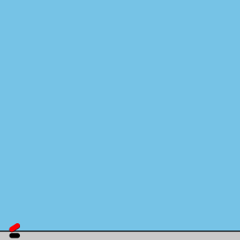

   How fast, in meters per second, is the shadow moving across the flat ground? The tolerance is $\pm 10$ m/s.

#### Question

2. At noon, on an [equinox](https://en.wikipedia.org/wiki/Equinox), at the equator, the sun is directly overhead. Over land with minimal elevation change, we can approximate the local ground as flat.

   A rocket is launched at an angle of elevation of 48.9° above the horizon at a speed of 4720 meters per second.

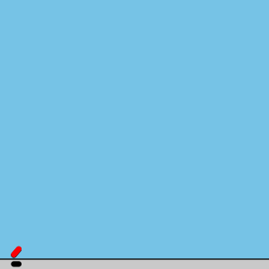

   How fast, in meters per second, is the shadow moving across the flat ground? The tolerance is $\pm 10$ m/s.

#### Question

3. At noon, on an [equinox](https://en.wikipedia.org/wiki/Equinox), at the equator, the sun is directly overhead. Over land with minimal elevation change, we can approximate the local ground as flat.

   A rocket is launched at an angle of elevation of 28.9° above the horizon at a speed of 4700 meters per second.

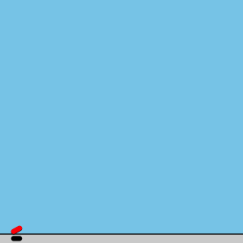

   How fast, in meters per second, is the shadow moving across the flat ground? The tolerance is $\pm 10$ m/s.

#### Question

4. At noon, on an [equinox](https://en.wikipedia.org/wiki/Equinox), at the equator, the sun is directly overhead. Over land with minimal elevation change, we can approximate the local ground as flat.

   A rocket is launched at an angle of elevation of 68.8° above the horizon at a speed of 3980 meters per second.

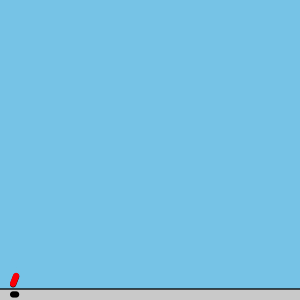

   How fast, in meters per second, is the shadow moving across the flat ground? The tolerance is $\pm 10$ m/s.

#### Question

5. At noon, on an [equinox](https://en.wikipedia.org/wiki/Equinox), at the equator, the sun is directly overhead. Over land with minimal elevation change, we can approximate the local ground as flat.

   A rocket is launched at an angle of elevation of 52° above the horizon at a speed of 2190 meters per second.

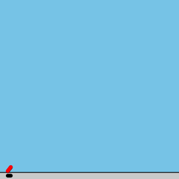

   How fast, in meters per second, is the shadow moving across the flat ground? The tolerance is $\pm 10$ m/s.

#### Question

6. At noon, on an [equinox](https://en.wikipedia.org/wiki/Equinox), at the equator, the sun is directly overhead. Over land with minimal elevation change, we can approximate the local ground as flat.

   A rocket is launched at an angle of elevation of 29.1° above the horizon at a speed of 2530 meters per second.

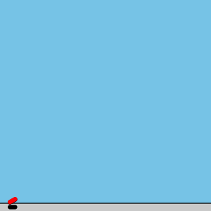

   How fast, in meters per second, is the shadow moving across the flat ground? The tolerance is $\pm 10$ m/s.

#### Question

7. At noon, on an [equinox](https://en.wikipedia.org/wiki/Equinox), at the equator, the sun is directly overhead. Over land with minimal elevation change, we can approximate the local ground as flat.

   A rocket is launched at an angle of elevation of 55.1° above the horizon at a speed of 3150 meters per second.

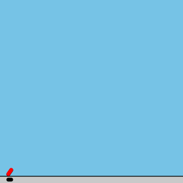

   How fast, in meters per second, is the shadow moving across the flat ground? The tolerance is $\pm 10$ m/s.

#### Question

8. At noon, on an [equinox](https://en.wikipedia.org/wiki/Equinox), at the equator, the sun is directly overhead. Over land with minimal elevation change, we can approximate the local ground as flat.

   A rocket is launched at an angle of elevation of 59.6° above the horizon at a speed of 3490 meters per second.

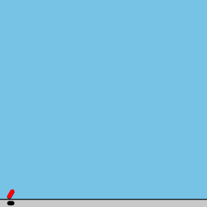

   How fast, in meters per second, is the shadow moving across the flat ground? The tolerance is $\pm 10$ m/s.